[figure not shown]

# 11 Prepare : Reading

## Objectives

- Review Matrix transforms and multiplication
- Please watch the videos and read the web page links below

Please review [matrices multplication](https://www.mathsisfun.com/algebra/matrix-multiplying.html)

## Reading

**Showing how to transform a point. Watch the other videos at Khan Academy.**

- https://www.khanacademy.org/math/precalculus/precalc-matrices/matrices-as-transformations/v/transforming-position-vector

**affine transformations**

- https://www.mathworks.com/discovery/affine-transformation.html
- http://math.hws.edu/graphicsbook/c2/s3.html

**Matrix multiplication**

- https://www.mathsisfun.com/algebra/matrix-multiplying.html

## 2D transformations

Here is a chart of different transformation matrices. These are for 2D transforms

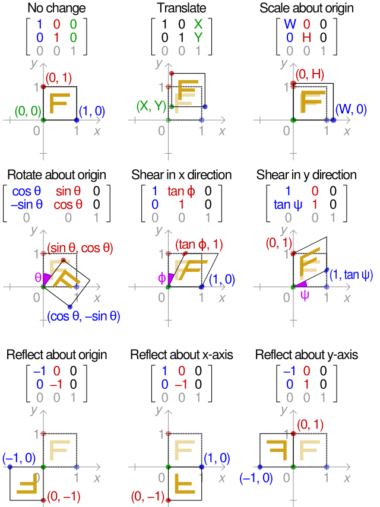

## 3D transformations

We will be focusing on three types of transforms for computer graphics. These matrices are likethe 2D versions, but with an added row and column. The biggest difference is for the rotation matrices as you have one for each rotation on an axis.

### Translate

In this matrice, notice the translate values are placed at the bottom of the matrice.

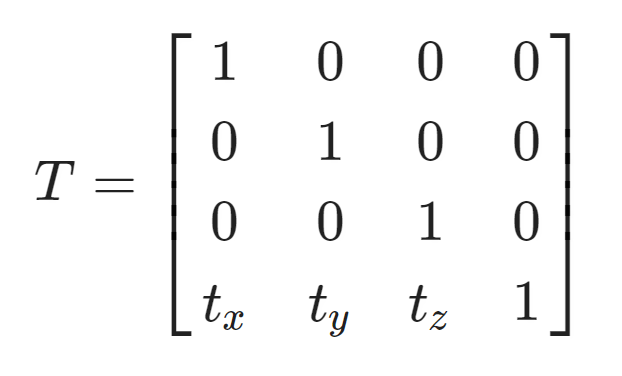

### Scale

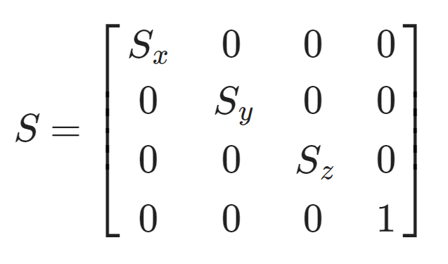

### Rotation

[Wikipedia On Rotation Matrices](https://en.wikipedia.org/wiki/Rotation_matrix)

> A basic rotation (also called elemental rotation) is a rotation about one of the axes of a coordinate system. The following three basic rotation matrices rotate vectors by an angle θ about the x-, y-, or z-axis, in three dimensions, using the right-hand rule—which codifies their alternating signs. (The same matrices can also represent a clockwise rotation of the axes.

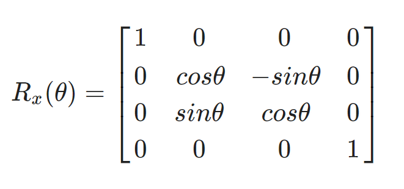

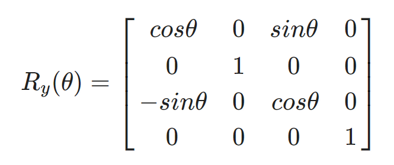

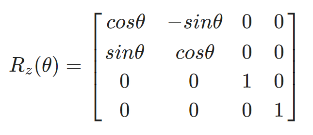

## Combining matricies

Using the three main matrices in computer graphics (ie., translation, scale and rotation), there are a number of methods to join them together. The method used is called "TRS". This means that we translate first, then rotations, then scale.